# Data Analysis and Statistical Inference

# Introduction

Global warming is an important issue which might affect future generation. Scientific community agrees that the greenhouse effect is responsible for global warming with discussion focused on to what extend the human activity is changing this process [2].

Unfortunately over the last decade, this topic has become highly politicized, with strong indication that political lobbing is overtaking rational discussion, leading to polarisation of the opinions. Given that, it is possible that interest in politics (exposure to political pundits, comments and lobbing) can translate to very polarised anty-global warming views. This lead me to my research question:

*“Does interest in politics affects ones views of the global warming.”*

Why should we care? Thix question is a proxy for a more complex phenomena - if we can’t agree on simple fact, we will fail to establish a dialog leading to discussion and eventual solution. and understand each other. Indication that politics lead is down this path would be a bad sign indeed.

# Data collection

To answer this question I will be using **American National Elections Study, 2012 Time Series Study Coursera Extract** [1]. I will be looking at following variables:

- INTEREST_ATTENTION answering question *How often do you pay attention to what’s going on in government and politics?*
- ENVIR_GWARM answering question *You may have heard about the idea that the world’s temperature may have been going up slowly over the past 100 years. What is your personal opinion on this?*

As discussed in next section, we have a total of 5384 cases - responses from the correspondents (face to face or online). Both variables are categorical. This is the observational study, as correspondents have been surveyed about their current opinion. A random sampling, based on address have been conducted on sample of USA citizens 18 years or older. Data have been collected both in face to face interviews and on-line data collection.

Given that I believe that my findings can be generalised to the population. As study was voluntary, there is possibility of voluntary response bias, showing results more strongly opinionated than general population. To reduce this bias I will limit my analysis to people who answered both parts of the study (pre and post election) - this committment suggest more balance resonse.

This is observation data, so casual links between the variables of interest can’t be established.

# Exploratory data analysis

For further study I will only consider:

- people who responded to both Pre-Election And Post-Election Interviews (I believe this this committment suggest more balance resonse).
- people who gave answers to both questions (removed 126 not complete cases).

```r
load(url("http://bit.ly/dasi_anes_data"))

columns2Keep = c('caseid','interest_attention','envir_gwarm')

anes = anes[anes$wave_completions == 'Yes (Pre-Election And Post-Election Interviews Completed)',columns2Keep]
anes <- anes[complete.cases(anes),] #remove participants with any of data missing
str(anes)
```

```
## 'data.frame':    5384 obs. of  3 variables:
##  $ caseid            : int  2 3 4 5 7 9 10 11 12 13 ...
##  $ interest_attention: Factor w/ 5 levels "Always","Most Of The Time",..: 1 2 4 2 4 4 2 2 4 4 ...
##  $ envir_gwarm       : Factor w/ 2 levels "Has Probably Been Happening",..: 2 1 1 1 2 1 1 1 1 1 ...
```

```r
summary(anes)
```

```
##      caseid               interest_attention
##  Min.   :   2   Always             : 955
##  1st Qu.:1530   Most Of The Time   :1800
##  Median :3938   About Half The Time:1145
##  Mean   :3606   Some Of The Time   :1352
##  3rd Qu.:5389   Never              : 132
##  Max.   :6864
##                          envir_gwarm
##  Has Probably Been Happening   :4384
##  Probably Hasn't Been Happening:1000
##
##
##
##
```

Overall we have 5384 cases - responses from the correspondents (face to face or online).

Lets visualise this data.

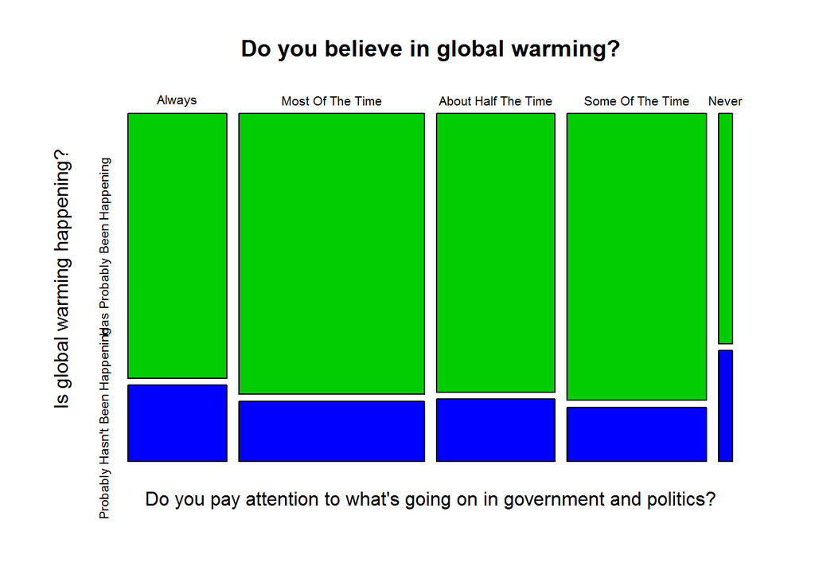

```r
globalWarmingBelievers = table(anes$interest_attention,anes$envir_gwarm)

mosaicplot(globalWarmingBelievers, main ="Do you believe in global warming?", xlab = "Do you pay attention to what's going on in government and politics?",ylab = "Is global warming happening?", color = 3:4)
```

Intial exploration of the data suggest that apart from extreme views (Never/Always) consensus is that global warming has been happening.

What is also interesting to notice is that extreme views on politics are not equal - there is much more people who always follow politics than ones who never follow. Both of thos groups are minority in the society.

# Inference

Following my reserach question *“Does interest in politics influence ones perception regarding the global warming”*, I will state following hipothesis

$H_0:$ Interest in politics does not affect ones views about global warming and proportion of people beliving in global warming is constant across all groups.

$H_A:$ Interest in politics influence ones views about global warming.

To prove my theory I will run $\chi^2$ test of independence, thesing if selected categorical variables are dependent of each other.

## Check conditions

In order to use $\chi^2$ test of independence sample has to be:

- independent - test description indicate that samples (cases) have been random, consist <10% of population and each case is counted only once
- each scenario (interest in politics) nave at least 5 expected cases

## Results

```r
source("http://bit.ly/dasi_inference")

inference(y = anes$envir_gwarm, x = anes$interest_attention, est = "proportion", type = "ht",  alternative = "greater", method = "theoretical",eda_plot = FALSE, inf_plot = FALSE )
```

```
## Response variable: categorical, Explanatory variable: categorical
## Chi-square test of independence
##
## Summary statistics:
##                                 x
## y                                Always Most Of The Time
##   Has Probably Been Happening       741             1482
##   Probably Hasn't Been Happening    214              318
##   Sum                               955             1800
##                                 x
## y                                About Half The Time Some Of The Time
##   Has Probably Been Happening                    935             1137
##   Probably Hasn't Been Happening                 210              215
##   Sum                                           1145             1352
##                                 x
## y                                Never  Sum
##   Has Probably Been Happening       89 4384
##   Probably Hasn't Been Happening    43 1000
##   Sum                              132 5384
##
## H_0: Response and explanatory variable are independent.
## H_A: Response and explanatory variable are dependent.
## Check conditions: expected counts
##                                 x
## y                                Always Most Of The Time
##   Has Probably Been Happening    777.62          1465.68
##   Probably Hasn't Been Happening 177.38           334.32
##                                 x
## y                                About Half The Time Some Of The Time
##   Has Probably Been Happening                 932.33          1100.89
##   Probably Hasn't Been Happening              212.67           251.11
##                                 x
## y                                 Never
##   Has Probably Been Happening    107.48
##   Probably Hasn't Been Happening  24.52
##
##  Pearson's Chi-squared test
##
## data:  y_table
## X-squared = 33.797, df = 4, p-value = 8.202e-07
```

Results indicate that response and explanatory variable are dependent. Following analysis of the data in the previos section I can assume that this is mostly to responses from extreme views (Never/Always) and otherwise citizens behaviour is not affected.

## Do extreme views (Never/Always) skew results?

```r
source("http://bit.ly/dasi_inference")

allowedResponses = levels(anes$interest_attention)
allowedResponses = allowedResponses[2:4] #remove extreme responses

nonExtremeCorrespondents = anes[anes$interest_attention %in% allowedResponses,]
nonExtremeCorrespondents$interest_attention = factor(nonExtremeCorrespondents$interest_attention) #remove dropped levels

inference(y = nonExtremeCorrespondents$envir_gwarm, x = nonExtremeCorrespondents$interest_attention, est = "proportion", type = "ht",  alternative = "greater", method = "theoretical",eda_plot = FALSE, inf_plot = FALSE )
```

```
## Response variable: categorical, Explanatory variable: categorical
## Chi-square test of independence
##
## Summary statistics:
##                                 x
## y                                Most Of The Time About Half The Time
##   Has Probably Been Happening                1482                 935
##   Probably Hasn't Been Happening              318                 210
##   Sum                                        1800                1145
##                                 x
## y                                Some Of The Time  Sum
##   Has Probably Been Happening                1137 3554
##   Probably Hasn't Been Happening              215  743
##   Sum                                        1352 4297
##
## H_0: Response and explanatory variable are independent.
## H_A: Response and explanatory variable are dependent.
## Check conditions: expected counts
##                                 x
## y                                Most Of The Time About Half The Time
##   Has Probably Been Happening             1488.76              947.02
##   Probably Hasn't Been Happening           311.24              197.98
##                                 x
## y                                Some Of The Time
##   Has Probably Been Happening             1118.22
##   Probably Hasn't Been Happening           233.78
##
##  Pearson's Chi-squared test
##
## data:  y_table
## X-squared = 2.8826, df = 2, p-value = 0.2366
```

```r
USAConsensus= table(nonExtremeCorrespondents$envir_gwarm)/length(nonExtremeCorrespondents$envir_gwarm)
```

Without extreme cases there is no evidence to reject $H_0$ hypothesis.

# Conclusion

While groups with very strong belies (Always/Never) are smaller then other ones it would be important to explore them further and understand how those group differ from other people? Are there any other characteristics that set them apart?

Probably most interesting here are citizens who not following politics, despite being much smaller then other groups - it would be important to understand what makes them hold views different to rest of the society.

# References

[1] American National Election Studies (ANES; www.electionstudies.org). The ANES 2012 Time Series Study [dataset]. Stanford University and the University of Michigan [producers].

Further information about the dataset can be found at https://d396qusza40orc.cloudfront.net/statistics%2Fproject%2Fanes1.html#envir_gwarm. Full description of study can be accessed at http://electionstudies.org/studypages/anes_timeseries_2012/anes_timeseries_2012_userguidecodebook.pdf

[2] Silver, Nate (2012-09-27). The Signal and the Noise: The Art and Science of Prediction (p. 376). Penguin Books Ltd. Kindle Edition have been used.

# Appendix

Attached is the sample of my final dataset

```r
head(anes,40)
```

```
##    caseid  interest_attention                    envir_gwarm
## 2       2              Always Probably Hasn't Been Happening
## 3       3    Most Of The Time    Has Probably Been Happening
## 4       4    Some Of The Time    Has Probably Been Happening
## 5       5    Most Of The Time    Has Probably Been Happening
## 7       7    Some Of The Time Probably Hasn't Been Happening
## 9       9    Some Of The Time    Has Probably Been Happening
## 10     10    Most Of The Time    Has Probably Been Happening
## 11     11    Most Of The Time    Has Probably Been Happening
## 12     12    Some Of The Time    Has Probably Been Happening
## 13     13    Some Of The Time    Has Probably Been Happening
## 14     14 About Half The Time    Has Probably Been Happening
## 15     15              Always Probably Hasn't Been Happening
## 17     17              Always    Has Probably Been Happening
## 18     18    Most Of The Time    Has Probably Been Happening
```

[output cut: 26 more lines]